# LLM embeddings vs. traditional sentiment on earnings calls — v2

A comparative backtest on a 100-ticker Nasdaq-100 universe, extended with earnings-window CAR3 and a nested-α factor-model test

Author

FINM 33200 final project

Published

May 26, 2026

## 1. Motivation

Earnings calls are the densest periodic information event in equity markets. A two-hour call typically contains prepared remarks from management, Q&A with sell-side analysts, and forward guidance — material that moves prices on the day and continues to be re-priced through the subsequent quarter as investors digest the language.

This project asks a narrow version of a long-running empirical-asset-pricing question: **do modern LLM embeddings of earnings-call transcripts carry cross-sectional return information beyond what a traditional lexicon and the standard non-text factors already provide?** The recent S&P Global Market Intelligence whitepaper (Ao and Zhao, 2025) tackles the same question at Russell-3000 scale with a fine-tuned LLM and reports the LLM signal roughly doubles a Loughran-McDonald lexicon baseline. We replicate the *shape* of that question on a smaller, fully reproducible setting:

- **Universe:** 100 Nasdaq-100 tickers drawn from the current index membership. Fixed list, no point-in-time membership.
- **Embeddings:** off-the-shelf OpenAI `text-embedding-3-small`, no fine-tuning.
- **Backtest machinery:** identical across all five signals — monthly rebalance, top-quintile / bottom-quintile equal-weighted long-short (top and bottom 20 % of valid signal values each month), 21-trading-day holding period, no transaction costs.

The project is **comparative**, not absolute. Universe, holding period, ranking rule, and benchmark are identical across signals; what differs is the signal value used to rank stocks at each month-end. Statements made below about a signal’s performance are statements about its rank position relative to the five others on this universe, on this window, under this spec — not claims about a deployable trading strategy.

**v2 additions (this writeup).** Three things change relative to the original v1 writeup:

1. A **6th first-class signal — CAR3** (announcement-window cumulative return, 3 trading days centered on `event_date`) is added so that the panel-defence question *“isn’t the LLM signal just earnings news the price already reflects?”* has an explicit stock-level control.
2. A **new §5.4 signal correlation matrix** shows how the six signals relate at both the stock level (Spearman, diagnoses §5.5 joint-FM multicollinearity) and the portfolio level (Pearson, diagnoses §5.6 α-regression multicollinearity).
3. A **new §5.6 nested time-series α progression** regresses each text strategy’s LS return on Fama-French 5 factors + Mom + CAR3 + Rev controls. This is the conventional Carhart-style factor-adjusted α test the v1 writeup did not include.

The v1 writeup remains at `reports/writeup.html` as the original 5-signal reference. The original 5 strategies’ backtest results are by-design unchanged between v1 and v2 — the additions are purely additive.

## 2. The six signals

Six cross-sectional long-short signals run on identical backtest machinery. What differs is only the signal value used to rank stocks at each month-end.

| # | Signal | Family | What it measures |
| --- | --- | --- | --- |
| 1 | **Anchor cosine on Δ sentiment** | LLM, hand-anchored | Projection of the call vector onto a 10-sentence positive-minus-negative direction, quarter-over-quarter change |
| 2 | **Ridge + PCA on Δ call vectors** | LLM, learned | RidgeCV on PCA(50) of the 1,536-D embedding delta + `days_since_earnings`, supervised on 21-day forward returns |
| 3 | **Loughran-McDonald Δ net positivity** | Lexicon | Bag-of-words match against the LM Positive / Negative dictionaries, net-positivity Δ between consecutive calls |
| 4 | **Price momentum 12-1** | Non-text factor | Standard cross-sectional momentum, last 12 months excluding the most recent |
| 5 | **Analyst revisions in Δ blended-forward net income** | Non-text factor | 21-business-day percentage change in Bloomberg’s `BEst Net Income` 1BF (blended-forward 12-month) consensus |
| 6 | **CAR3 — earnings-window cumulative return** | Earnings-news factor | 3-trading-day cumulative simple return $px[t+1] / px[t-1] - 1$ centred on `event_date`; carried forward 60 days |

Signals (1)–(3) are computed per earnings call and carried forward at month-end until the next call refreshes them. Signal (6) is also computed per earnings call and carried forward. Signals (4)–(5) refresh independently every month from prices and Bloomberg consensus.

The two LLM signals (1 and 2) are **both first-class methodological tests**, not a “cheap baseline plus the real one”. Strategy 1 takes the embedding and forces all interpretive burden onto ten hand-written anchor sentences; Strategy 2 lets supervised learning identify return-relevant directions in the embedding delta. They answer different questions — *“is hand-written semantic distance informative?”* vs *“is there a learnable signal in the raw call-to-call shift?”* — and the comparison between them is itself part of the result. Strategies 3–6 are the four benchmarks the LLM signals have to beat to claim incremental information over the lexicon, the standard cross-sectional factors, and the announcement-window earnings reaction.

### 2.1 Anchor cosine on Δ sentiment (LLM, hand-anchored)

We hand-write five “positive” sentences (e.g. *“We had a record-breaking quarter with strong revenue growth”*) and five “negative” sentences (*“We are lowering our outlook due to weak demand and macro headwinds”*). Each anchor list is embedded and pooled to a single L2-normalised vector $a_{\text{pos}}$ / $a_{\text{neg}}$. For every earnings call $(i, t)$ the per-call sentiment-diff score is

$$s_{i,t} = \cos(v_{i,t}, a_{\text{pos}}) - \cos(v_{i,t}, a_{\text{neg}})$$

and the ranking signal (stored in the panel as `sig_anchor`) is its call-to-call change $\Delta s_{i,t} = s_{i,t} - s_{i,t-1}$, where $v_{i,t}$ is the per-call vector (§3) and $t-1$ is the same ticker’s previous call. Working in Δ removes a company-fixed-effect direction: some industries naturally talk more about R&D, some more about logistics, and the *level* of cosine is contaminated by that; the *change* isolates the new language of the quarter.

### 2.2 Ridge + PCA on Δ call vectors (LLM, learned)

Instead of projecting onto a hand-written direction, we let supervised learning pick the directions. Per call, the feature vector is the 1,536-D Δ-call vector concatenated with $\tau_{i,t}$ = calendar days since the prior call (`days_since_earnings` in the panel, a freshness control). A 7-year training window (2012-2018) feeds an expanding-window pipeline of `PCA(n_components=50)` → `StandardScaler` → `RidgeCV` over $\alpha \in \{0.01, 0.1, 1, 10, 100, 1000\}$ with `TimeSeriesSplit(5)`. PCA is necessary: with the raw 1,537-D feature vector, RidgeCV saturated at $\alpha = 1000$ in every fold and the resulting long-short Sharpe was ~0.05; collapsing the embedding delta to 50 PCs first gives ridge something it can actually regularise. The frozen model from year $Y-1$ scores all calls in year $Y$; the predicted 21-day forward return is stored as `sig_ridge`.

**Why this method.** It is the strict cross-validation answer to *“is there a return-predictive direction in the raw embedding delta that anchor cosine can’t see?”* With PCA pre-reduction the model survives cross-validation and produces an out-of-sample Sharpe well above the LM lexicon’s.

**Why much fewer months than the others.** The ridge model requires a long warm-up to estimate PCA loadings and the optimal $\alpha$. We hold out 2012–2018 entirely as a training window, so the first ridge prediction lands in **February 2019**. Every other signal in the panel uses the full history back to 2005-2008. This is why the ridge row of every results table shows ~86 months while the other rows show 150–300+ months. The post-2018 subsample (§5.2) puts every strategy on the same shorter window for a fair apples-to-apples comparison.

### 2.3 Loughran-McDonald Δ net positivity (Lexicon)

The classical text-NLP baseline. We tokenise the full transcript and count tokens in the LM Positive list ($A_{i,t}$) and the LM Negative list ($B_{i,t}$). The per-call LM net-positivity score is

$$L_{i,t} = \frac{A_{i,t} - B_{i,t}}{A_{i,t} + B_{i,t}}$$

and the ranking signal (panel column `sig_lm`) is its call-to-call change $\Delta L_{i,t} = L_{i,t} - L_{i,t-1}$.

Only Positive and Negative are used. The other LM categories (Uncertainty, Litigious, Strong/Weak Modal, Constraining) are not standard ingredients of net positivity and are excluded by design. Calls with zero LM-listed words are dropped.

**Why this method.** Loughran and McDonald (2011) is the canonical finance-domain lexicon and the S&P whitepaper’s own benchmark. Including it here lets us answer “does an LLM-embedding signal beat the lexicon-counting signal on this universe?” — the same comparative shape as S&P’s headline.

### 2.4 Price momentum 12-1 (Non-text factor)

Standard cross-sectional momentum. At month-end $m$ the signal is the cumulative simple total return from 12 months ago to one month ago,

$$M_{i,m} = \prod_{k=2}^{12}(1 + r_{i,m-k}) - 1$$

(panel column `sig_mom`). The most recent month is skipped to dodge the well-known one-month reversal effect.

**Why this method.** Jegadeesh and Titman (1993). It is the equity factor every quant practitioner already has. If a text-derived signal cannot beat 12-1 momentum, it is not adding much.

### 2.5 Analyst revisions in Δ blended-forward net income (Non-text factor)

Let $B_{i,m}$ denote the Bloomberg consensus `BEst Net Income` for ticker $i$ at month-end $m$. At month-end $m$, the ranking signal (panel column `sig_rev`) is the 21-business-day percentage change in that consensus, normalised by its absolute prior value:

$$R_{i,m} = \frac{B_{i,m} - B_{i,m-21}}{\left| B_{i,m-21} \right|}$$

The Bloomberg field is `BEST_NET_INCOME`, which under Bloomberg’s default `1BF` (“1-blended-forward”) methodology is **not raw FY1 net income** — it is a days-weighted blend of FY1 and FY2 (or FY2 and FY3 once the FY1 reporting date has passed):

$$B = \tfrac{d}{D}\cdot\mathrm{FY1} + \left(1 - \tfrac{d}{D}\right)\cdot\mathrm{FY2}$$

where $d$ is the number of trading days until the next fiscal year-end and $D$ is the trading days in a year. This is the definition Bloomberg documents directly on the `Info` sheet of the company-data workbook we use to pull the consensus.

**Why this method.** Estimate revisions are the second standard non-text factor (after price momentum) that any equity strategy is built against. The 21-business-day window aligns the revision horizon with the forward-return horizon used everywhere else in the project.

### 2.6 CAR3 — earnings-window cumulative return (Earnings-news factor)

For each earnings call at `event_date` $t$, CAR3 is the 3-trading-day cumulative simple return centred on the announcement,

$$\mathrm{CAR3}_{i,t} = \frac{p_{i, t+1}}{p_{i, t-1}} - 1,$$

where $p_{i, t-1}$ is the close on the trading day immediately before the announcement and $p_{i, t+1}$ is the close on the trading day immediately after. The window is the literature-standard $[-1, +1]$ announcement window (Beaver 1968; Ball-Brown 1968 idiom for the announcement reaction; this is NOT the longer post-event drift that “PEAD” denotes — that runs roughly $[+2, +60]$). We use the raw cumulative return, not market-adjusted, to keep the cross-sectional ranking consistent with the project’s universe-relative convention (every other signal is ranked on raw values; the equal-weight benchmark in §4 already normalises for the market drift).

The per-call CAR3 is carried forward 60 calendar days per ticker (panel column `sig_car3`), the same mechanism that anchor / ridge / LM signals use (§4.8 of the methodology spec). The 60-day window is well-justified by the PEAD literature on the announcement-effect-decay horizon; a more aggressive `days_since_earnings > 60` filter would be appropriate for a separate post-event-drift specification.

**Why this method.** Two reasons. First, it is the simplest *price-based* control for “did the earnings announcement itself contain news?” — if the LLM-text signal’s edge is just picking up that earnings beat or missed expectations, then CAR3 should absorb most of that edge in the §5.5 joint regression and §5.6 nested α progression. Second, the announcement-window CAR is a well-documented stand-alone anomaly (the announcement-return premium); including it as a 6th first-class signal lets us check whether its LS return is meaningful on this Nasdaq-100 universe.

**Why not the post-event drift window?** The longer $[+2, +60]$ window is the classical PEAD signal; it would overlap the 21-trading-day forward-return target of the project’s backtest, creating a measurement-period contamination. The $[-1, +1]$ window is clean of that: the announcement window is over before the project’s forward-return clock starts on the next month-end.

## 3. Data

### 3.1 Universe

100 Nasdaq tickers drawn from current Nasdaq-100 membership. The list is **fixed across the entire backtest period** — no point-in-time index reconstitution. The transcript-derived signals (anchor, ridge, LM, CAR3) cover the 100 names where event dates exist; the price- and Bloomberg-derived signals (momentum, revisions) cover one additional name where coverage allows. CAR3 (signal 6) uses the same per-call event-date frame as the LM lexicon, applied to existing daily Bloomberg PX_LAST — no new external data pull is required.

**Survivorship bias.** Names that delisted, were acquired, or fell out of the index do not appear. Bias should largely cancel in the *relative* comparison across signals (they all see substantially the same universe), but symmetry of bias across signals is an assumption, not a verified property, and is named in §6.

### 3.2 Transcripts — what we pull and what we do with them

Full earnings-call transcripts are pulled from **WRDS Capital IQ** at the **component level**: one row per speech act, tagged with a section type (presentation operator message, presenter speech, Q&A operator message, question, answer, unknown Q&A message) and a speaker-type code for operator / management / analyst.

Each call is then **cleaned and section-parsed**, then rolled up to a single per-call `full_text` view. The cleaning step makes a handful of explicit assumptions that need calling out, since they are deliberate choices, not transparent defaults:

### 3.3 Embeddings — chunking and per-call pooling

Each cleaned per-call transcript is **chunked to fit the embedding model’s context window**:

1. Tokenise with `tiktoken` using the `text-embedding-3-small` encoder.
2. Walk the token sequence and start a new chunk whenever the running total exceeds **~6,000 tokens**.
3. If any single transcript component is longer than **7,500 tokens**, hard-split it before chunking.

The 6,000-token target sits comfortably below the model’s hard limit of 8,192 tokens — chosen with a margin so that no chunk ever truncates. The 7,500 hard-split threshold handles the rare case where a single uninterrupted management speech blows past one chunk’s worth on its own; it guarantees no single component is split across more than one chunk unnecessarily.

Each chunk is sent to **OpenAI `text-embedding-3-small`** (1,536-D, near-unit-norm). The **per-call vector** is the **`n_chars`-weighted mean** of the chunk embeddings, re-normalised to unit length. Character-weighting (rather than uniform) means longer prepared sections naturally dominate the per-call representation in proportion to how much they say — the same property a human reader would apply. The per-call vector is what enters every LLM-based signal (anchor cosine and ridge); the per-call $\Delta v_{i,t} = v_{i,t} - v_{i,t-1}$ enters as the supervised feature.

### 3.4 Prices and analyst estimates

Daily prices and the Bloomberg consensus `BEst Net Income` come from **Bloomberg Terminal exports**, pulled manually into a workbook and parsed into the analysis pipeline. Prices are converted to a monthly panel (last business day of month) and to 21-trading-day forward returns aligned to each earnings-call event date for the ridge model. The `BEst Net Income` field is the Bloomberg `1BF` blended-forward measure described in §2.5.

### 3.5 Loughran-McDonald dictionary

The Loughran-McDonald master dictionary — 86,554 words with seven finance-specific category flags. Only Positive and Negative are used for the LM baseline, following standard practice.

## 4. Headline results

### 4.1 Return / risk metrics, full history per strategy

Table 1

|  | Strategy | Ann. return | Ann. vol | Sharpe | Max DD | Hit rate | IR vs. bench | Months |
| --- | --- | --- | --- | --- | --- | --- | --- | --- |
| 0 | 1. Anchor cosine (LLM) | +4.6% | +10.8% | +0.42 | -25.3% | +60.4% | -0.73 | 230 |
| 1 | 2. Ridge + PCA (LLM) | +4.6% | +11.3% | +0.41 | -20.3% | +52.3% | -0.88 | 86 |
| 2 | 3. LM lexicon | +2.5% | +12.0% | +0.21 | -22.5% | +57.0% | -0.83 | 230 |
| 3 | 4. Momentum 12-1 | +1.8% | +21.0% | +0.08 | -64.1% | +51.0% | -0.65 | 243 |
| 4 | 5. Analyst revisions | +9.4% | +16.5% | +0.57 | -35.4% | +55.6% | -0.51 | 248 |
| 5 | 6. CAR3 (earnings-window) | +0.6% | +14.7% | +0.04 | -63.9% | +51.3% | -0.89 | 236 |

**Column glossary.**

- **Ann. return / Ann. vol** — mean monthly long-short return × 12, and std dev × √12.
- **Sharpe** — annualised return ÷ annualised vol, with zero risk-free rate.
- **Max DD** — worst peak-to-trough drawdown on the cumulative long-short series.
- **Hit rate** — share of months with positive long-short return. 50 % = coin-flip.
- **IR vs. bench** — *Information Ratio* against the benchmark. The benchmark is the **equal-weighted return of the universe with non-null signal that month** (not the cap-weighted Nasdaq-100; equal-weight matches how the long and short legs are themselves weighted). Specifically: $\text{IR} = \text{mean}(r_{LS} - r_{\text{bench}}) \cdot 12 \big/ \text{std}(r_{LS} - r_{\text{bench}}) \cdot \sqrt{12}$. The long-short series is dollar-neutral while the universe drifted up over the sample, so the difference $r_{LS} - r_{\text{bench}}$ is mechanically negative on average — every IR row is therefore negative. The comparative reading is *which signal’s IR is least negative*, not the sign in isolation.
- **Months** — number of monthly observations behind the row.

### 4.2 Cross-sectional Spearman rank IC

The Information Coefficient (IC) at month $m$ is the Spearman rank correlation between the signal value and the realised 21-day forward return across the cross-section that month. It measures whether the **full ordering** of stocks lined up with returns — a complement to the long-short return, which depends only on the top-quintile and bottom-quintile tails.

Table 2

|  | Strategy | Spearman IC mean | Spearman IC std | IC info-ratio | % months IC > 0 | Months |
| --- | --- | --- | --- | --- | --- | --- |
| 0 | 1. Anchor cosine (LLM) | +0.0132 | 0.1242 | +0.11 | 52.9% | 240 |
| 1 | 2. Ridge + PCA (LLM) | +0.0140 | 0.1237 | +0.11 | 52.9% | 87 |
| 2 | 3. LM lexicon | -0.0013 | 0.1219 | -0.01 | 49.2% | 240 |
| 3 | 4. Momentum 12-1 | +0.0066 | 0.2082 | +0.03 | 51.4% | 243 |
| 4 | 5. Analyst revisions | +0.0238 | 0.1703 | +0.14 | 55.8% | 251 |
| 5 | 6. CAR3 (earnings-window) | +0.0087 | 0.1260 | +0.07 | 50.2% | 243 |

### 4.3 Hit rate by strategy

The fraction of **rebalance months** in which the long-short return was positive. Each month produces one number per strategy — the equal-weighted average return of the top-quintile names minus the equal-weighted average return of the bottom-quintile names over the 21-day holding period — and the hit rate counts what share of those monthly numbers came out greater than zero. A hit rate of 0.55 therefore means “in 55 out of every 100 months, the long leg outperformed the short leg”.

A couple of things this metric is *not*: it is not the share of individual stocks in the long leg that beat their benchmark, and it is symmetric on the sign — a $-5 \%$ month and a $+0.01 \%$ month both count identically. 50 % is the coin-flip baseline. A hit rate near 0.5 paired with a positive Sharpe means the *magnitude* of wins drives the return (a few big winners offset many small losers); a higher hit rate paired with a modest Sharpe means the *frequency* of wins does (steady small wins).

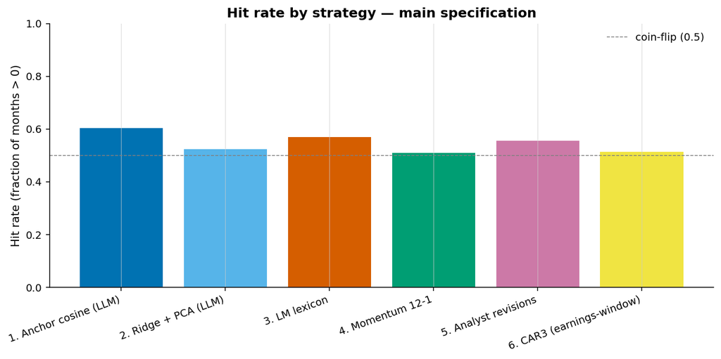

Hit rate by strategy — main specification.

### 4.4 Cumulative long-short return, common window

Ridge + PCA has predictions only from February 2019 onward (it needs a long training window). The chart below restricts every strategy to that common window so endpoints are comparable.

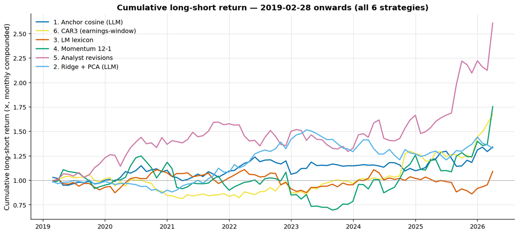

Cumulative long-short return — 2019-02 onwards (all 6 strategies).

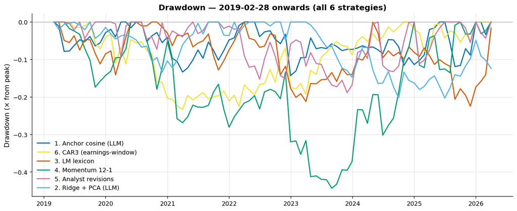

Drawdown — 2019-02 onwards (all 6 strategies).

For a longer-window view of the four signals that do not depend on the ridge model:

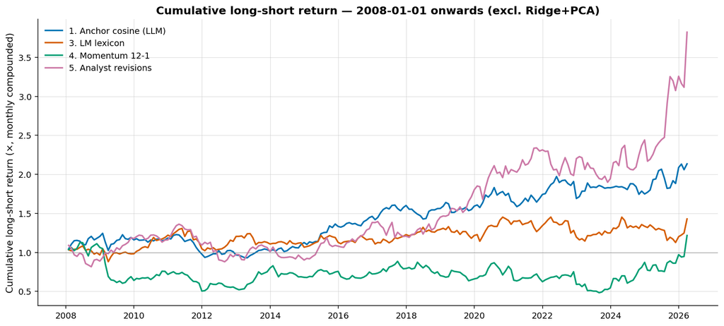

Cumulative long-short return — 2008-01 onwards (excl. Ridge + PCA).

## 5. Robustness

### 5.1 Stale-call exclusion

If `Sharpe_stale > Sharpe_main`, the carried-forward stale signal was adding noise and the signal is concentrated near the earnings event.

Table 3

|  | Strategy | Ann. return | Ann. vol | Sharpe | Max DD | Hit rate | IR vs. bench | Months |
| --- | --- | --- | --- | --- | --- | --- | --- | --- |
| 0 | 1. Anchor cosine (LLM) | +10.8% | +13.3% | +0.82 | -12.2% | +61.4% | -0.47 | 171 |
| 1 | 2. Ridge + PCA (LLM) | +4.3% | +12.5% | +0.34 | -30.2% | +46.8% | -0.86 | 77 |
| 2 | 3. LM lexicon | +5.9% | +12.2% | +0.48 | -19.2% | +56.1% | -0.70 | 171 |
| 3 | 4. Momentum 12-1 | +1.8% | +21.0% | +0.08 | -64.1% | +51.0% | -0.65 | 243 |
| 4 | 5. Analyst revisions | +9.4% | +16.5% | +0.57 | -35.4% | +55.6% | -0.51 | 248 |
| 5 | 6. CAR3 (earnings-window) | +1.4% | +15.2% | +0.09 | -38.5% | +51.4% | -0.84 | 173 |

### 5.2 Post-2018 subsample

Restricting the entire main-spec backtest to `event_date ≥ 2018-01-01`. Tests whether signal performance is driven by the early part of the sample or persists into the recent regime — mirroring the S&P observation that the lexicon baseline has weakened over time.

Table 4

|  | Strategy | Ann. return | Ann. vol | Sharpe | Max DD | Hit rate | IR vs. bench | Months |
| --- | --- | --- | --- | --- | --- | --- | --- | --- |
| 0 | 1. Anchor cosine (LLM) | +5.0% | +11.7% | +0.42 | -14.3% | +61.4% | -0.90 | 88 |
| 1 | 2. Ridge + PCA (LLM) | +4.6% | +11.3% | +0.41 | -20.3% | +52.3% | -0.88 | 86 |
| 2 | 3. LM lexicon | +2.3% | +13.4% | +0.17 | -22.5% | +53.4% | -1.03 | 88 |
| 3 | 4. Momentum 12-1 | +9.8% | +25.6% | +0.38 | -44.3% | +54.5% | -0.50 | 88 |
| 4 | 5. Analyst revisions | +15.5% | +18.8% | +0.82 | -18.9% | +58.0% | -0.46 | 88 |
| 5 | 6. CAR3 (earnings-window) | +8.7% | +15.7% | +0.56 | -23.3% | +55.7% | -0.72 | 88 |

### 5.3 Rolling 12-month IC

Twelve-month trailing mean of the monthly Spearman IC. Each strategy’s line begins when it accumulates enough months of IC observations.

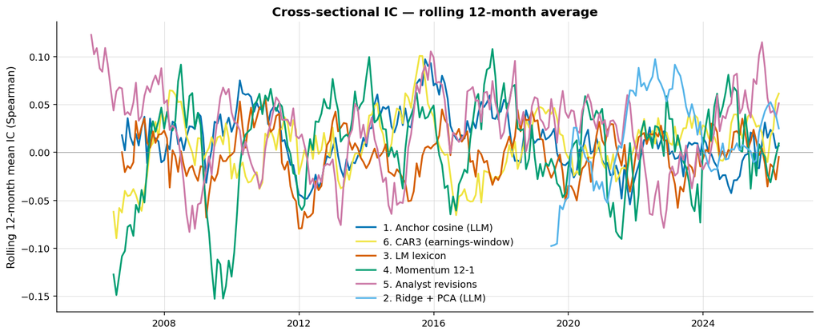

Cross-sectional IC — rolling 12-month average.

### 5.4 Signal correlation matrices

Before running the joint regression (§5.5) or the time-series α progression (§5.6), it is worth showing how the six signals relate. Two views, two diagnostics:

**(a) Stock-level Spearman rank correlations** — computed on the *z-scored* signal panel pooled across all (ticker, month) observations. This is the diagnostic for §5.5: if two signals are r ≈ 0.9 here, their individual β coefficients in the joint regression will be unreliable from multicollinearity even if the joint loading is real.

Table 5

|  | Anchor | Ridge | LM | Mom | Rev | CAR3 |
| --- | --- | --- | --- | --- | --- | --- |
| Anchor | 1.000 | 0.076 | 0.328 | 0.024 | 0.046 | 0.134 |
| Ridge | 0.076 | 1.000 | -0.030 | -0.001 | -0.001 | 0.011 |
| LM | 0.328 | -0.030 | 1.000 | 0.016 | 0.050 | 0.147 |
| Mom | 0.024 | -0.001 | 0.016 | 1.000 | 0.190 | 0.147 |
| Rev | 0.046 | -0.001 | 0.050 | 0.190 | 1.000 | 0.133 |
| CAR3 | 0.134 | 0.011 | 0.147 | 0.147 | 0.133 | 1.000 |

**(b) Portfolio-level Pearson correlations** — computed on each strategy’s monthly long-short return series from the backtest. This is the diagnostic for §5.6: correlated factor portfolios on the RHS of the time-series α regression produce noisy individual coefficients.

Table 6

|  | Anchor cosine (LLM) | Ridge + PCA (LLM) | LM lexicon | Momentum 12-1 | Analyst revisions | CAR3 (earnings-window) |
| --- | --- | --- | --- | --- | --- | --- |
| Anchor cosine (LLM) | 1.000 | -0.080 | 0.433 | 0.153 | -0.005 | 0.214 |
| Ridge + PCA (LLM) | -0.080 | 1.000 | -0.284 | 0.042 | -0.005 | 0.180 |
| LM lexicon | 0.433 | -0.284 | 1.000 | 0.205 | 0.214 | 0.218 |
| Momentum 12-1 | 0.153 | 0.042 | 0.205 | 1.000 | 0.346 | 0.360 |
| Analyst revisions | -0.005 | -0.005 | 0.214 | 0.346 | 1.000 | 0.241 |
| CAR3 (earnings-window) | 0.214 | 0.180 | 0.218 | 0.360 | 0.241 | 1.000 |

### 5.5 Fama-MacBeth joint regression (6 signals)

Performance tables show each signal *in isolation*. The cleaner question is whether each one contributes information **after controlling for the other five**. That is what Fama-MacBeth answers.

**The regression, in one line.** Let $z^k_{i,m}$ denote the monthly cross-sectional z-score of signal $k$ for ticker $i$ at month-end $m$, where $k \in \{a, r, l, p, v, c\}$ — anchor cosine, ridge prediction, LM lexicon, price momentum, analyst revisions, CAR3. At each rebalance month $m$ we run a cross-sectional OLS of the 21-day forward return on all six z-scored signals simultaneously:

$$r_{i,m} = \alpha_m + \beta^m_a z^a_{i,m} + \beta^m_r z^r_{i,m} + \beta^m_l z^l_{i,m} + \beta^m_p z^p_{i,m} + \beta^m_v z^v_{i,m} + \beta^m_c z^c_{i,m} + \varepsilon_{i,m}$$

Z-scoring within each month is what makes the $\beta$’s comparable across signals: a $\beta$ of $+0.002$ means “a +1σ-of-this-signal move is associated with +20 bps of forward 21-day return, holding the other five signals constant”.

We then take the **time-series average** of each month’s coefficient: $\bar\beta_k = \tfrac{1}{T}\sum_m \beta^m_k$. Standard errors on $\bar\beta_k$ are **Newey-West HAC at lag 6**, which corrects for serial correlation in the monthly $\beta^m_k$ sequence. Lag 6 is the standard choice for monthly cross-sectional FM with autocorrelated coefficients; with 21-day-holding returns there is also mechanical overlap that NW handles.

A signal is **dropped from the joint regression** if its average cross-sectional coverage is below 20 tickers per month — otherwise a thin column would force the joint `dropna` to wipe out most rows of the panel.

```
Months: 87   mean R²: 0.1433   α: +0.0205   α t-stat: +4.47
```

Table 7

|  | Signal | β | NW SE | NW t |
| --- | --- | --- | --- | --- |
| 0 | Anchor cosine (LLM) | -0.0001 | 0.0010 | -0.06 |
| 1 | Ridge + PCA (LLM) | +0.0020 | 0.0012 | +1.63 |
| 2 | LM lexicon | +0.0001 | 0.0010 | +0.12 |
| 3 | Momentum 12-1 | +0.0053 | 0.0032 | +1.63 |
| 4 | Analyst revisions | +0.0015 | 0.0018 | +0.85 |
| 5 | CAR3 (earnings-window) | +0.0013 | 0.0011 | +1.19 |

**How to read this.** This is the strict *marginal* test: after the other five signals are in the regression, does this one still load? With monthly cross-sectional z-scoring, a coefficient is significant at the 5 % level when |t| > ~2. The joint $R^2$ above is the time-series average of the monthly cross-sectional $R^2$ — a low number is expected for one-month-ahead stock returns even on a six-signal regression. The intercept $\alpha$ is the average cross-sectional mean return that none of the six signals explains; a positive $\alpha$ with a high t-stat is simply the universe drifting up over the sample.

### 5.6 Nested time-series α progression

§5.5 tests whether each signal carries incremental information at the **stock level** in a joint cross-sectional regression. The complementary question is whether each LLM strategy’s **long-short portfolio return** generates α *beyond* a conventional factor-model baseline. This is the standard Carhart-style spanning test that every published asset-pricing anomaly paper runs.

**Baseline factor model.** Fama-French 5 factors (Mkt-RF, SMB, HML, RMW, CMA), pulled from the Ken French data library. We add the project’s own non-text strategies (Mom, CAR3, Rev) as *factor-mimicking long-short portfolios* in nested steps, so the question “does the LLM signal beat the standard factors AND the non-text controls?” is answered horizontally across columns.

**Why FF5 alone (not Carhart MOM)?** The Fama-French 2015 5-factor model was explicitly designed to subsume momentum. We deviate from the S&P / Ghosal convention (which uses FF+MOM or Carhart 4) by using FF5 alone as the baseline and adding momentum as an explicit control column. This lets the data speak on whether Strategy 4’s momentum is a real anomaly on this 100-Nasdaq universe rather than assuming it.

**For each text strategy $k \in \{\text{Ridge}, \text{Anchor}, \text{LM}\}$**, we run four nested OLS regressions of its monthly LS return on a growing factor set:

| Column | RHS factors | Tests |
| --- | --- | --- |
| α₀ | FF5 | Beyond Fama-French 5? |
| α₁ | FF5 + Mom-factor | Survives momentum control? |
| α₂ | FF5 + Mom + CAR3-factor | Survives earnings-news? |
| α₃ | FF5 + Mom + CAR3 + Rev-factor | Survives analyst revisions? |

Newey-West HAC standard errors (lag 6, consistent with §5.5). No risk-free-rate subtraction on the LHS — long-short portfolios are zero-cost so a funding-cost adjustment is mechanically inappropriate. The strategy LS series uses the project’s 21-trading-day spec; FF5 is calendar-month — we align by timestamp-shift (signal-date T joined to FF5’s next-month row). The residual ~1-2 business-day boundary mismatch is documented but not corrected; it does not change the sign or t-statistic of any reported α materially.

**How to read the tables below.** Read horizontally (α₀ → α₁ → α₂ → α₃) within a row to see how each strategy’s α decays as more controls are added: a signal whose α drops to zero after the CAR3 column is just picking up the earnings-day price reaction; a signal whose α survives all three controls is contributing unique information beyond standard factors AND non-text earnings news AND analyst revisions. Read vertically (Ridge vs Anchor vs LM at any column) for the project’s central LLM-vs-lexicon comparison after factor adjustment — this is the Ao-Zhao question, on this universe.

#### Full nested regression tables (own-history sample)

Each table below shows the **entire regression** — α, every factor’s β (with NW-HAC t-stat in parentheses), R², and N — for each of the 4 nested specs. Read across a row to see how a factor’s loading shifts as more controls are added (multicollinearity diagnostic — large shifts indicate the new factor is partly redundant with this one). Empty cells indicate the factor was not in that spec’s RHS.

##### Ridge

Table 8

|  | Factor | α₀ (FF5) | α₁ (+Mom) | α₂ (+CAR3) | α₃ (+Rev) |
| --- | --- | --- | --- | --- | --- |
| 0 | α (intercept, monthly) | +0.0042 (t=+1.13) | +0.0036 (t=+1.00) | +0.0033 (t=+0.85) | +0.0028 (t=+0.79) |
| 1 | MKT-RF | -0.0215 (t=-0.29) | -0.0220 (t=-0.31) | -0.0172 (t=-0.23) | -0.0224 (t=-0.31) |
| 2 | SMB | +0.2132 (t=+1.60) | +0.2291 (t=+1.73) | +0.1996 (t=+1.51) | +0.2072 (t=+1.50) |
| 3 | HML | -0.0229 (t=-0.32) | -0.0016 (t=-0.02) | -0.0104 (t=-0.12) | -0.0092 (t=-0.11) |
| 4 | RMW | +0.2042 (t=+1.49) | +0.2482 (t=+1.75) | +0.1968 (t=+1.13) | +0.2262 (t=+1.12) |
| 5 | CMA | -0.0047 (t=-0.03) | -0.0359 (t=-0.26) | -0.0141 (t=-0.09) | +0.0159 (t=+0.11) |
| 6 | Mom-factor |  | +0.0680 (t=+0.89) | +0.0437 (t=+0.58) | +0.0301 (t=+0.37) |
| 7 | CAR3-factor |  |  | +0.0898 (t=+0.86) | +0.0898 (t=+0.86) |
| 8 | Rev-factor |  |  |  | +0.0537 (t=+0.55) |
| 9 | R² | 0.0380 | 0.0566 | 0.0694 | 0.0736 |
| 10 | N (months) | 85 | 85 | 85 | 85 |

##### Anchor

Table 9

|  | Factor | α₀ (FF5) | α₁ (+Mom) | α₂ (+CAR3) | α₃ (+Rev) |
| --- | --- | --- | --- | --- | --- |
| 0 | α (intercept, monthly) | +0.0034 (t=+1.94) | +0.0031 (t=+1.78) | +0.0033 (t=+1.90) | +0.0037 (t=+2.03) |
| 1 | MKT-RF | -0.0113 (t=-0.18) | -0.0011 (t=-0.02) | -0.0003 (t=-0.01) | +0.0041 (t=+0.07) |
| 2 | SMB | -0.1096 (t=-1.22) | -0.1073 (t=-1.21) | -0.1255 (t=-1.44) | -0.1356 (t=-1.53) |
| 3 | HML | -0.1241 (t=-1.69) | -0.1002 (t=-1.40) | -0.1118 (t=-1.69) | -0.1168 (t=-1.79) |
| 4 | RMW | +0.0467 (t=+0.36) | +0.0804 (t=+0.61) | +0.0257 (t=+0.20) | -0.0022 (t=-0.02) |
| 5 | CMA | +0.2661 (t=+2.05) | +0.2528 (t=+1.93) | +0.2808 (t=+2.31) | +0.2564 (t=+2.07) |
| 6 | Mom-factor |  | +0.0695 (t=+1.45) | +0.0296 (t=+0.67) | +0.0383 (t=+0.89) |
| 7 | CAR3-factor |  |  | +0.1418 (t=+1.98) | +0.1522 (t=+2.10) |
| 8 | Rev-factor |  |  |  | -0.0562 (t=-1.07) |
| 9 | R² | 0.0425 | 0.0582 | 0.0901 | 0.0955 |
| 10 | N (months) | 229 | 229 | 229 | 229 |

##### LM

Table 10

|  | Factor | α₀ (FF5) | α₁ (+Mom) | α₂ (+CAR3) | α₃ (+Rev) |
| --- | --- | --- | --- | --- | --- |
| 0 | α (intercept, monthly) | +0.0020 (t=+1.09) | +0.0016 (t=+0.88) | +0.0018 (t=+0.97) | +0.0013 (t=+0.68) |
| 1 | MKT-RF | -0.0272 (t=-0.42) | -0.0156 (t=-0.25) | -0.0148 (t=-0.24) | -0.0206 (t=-0.34) |
| 2 | SMB | -0.0338 (t=-0.37) | -0.0311 (t=-0.35) | -0.0495 (t=-0.55) | -0.0364 (t=-0.42) |
| 3 | HML | +0.0562 (t=+0.73) | +0.0836 (t=+1.07) | +0.0718 (t=+0.99) | +0.0784 (t=+1.05) |
| 4 | RMW | -0.0761 (t=-0.51) | -0.0377 (t=-0.25) | -0.0926 (t=-0.62) | -0.0559 (t=-0.37) |
| 5 | CMA | -0.0614 (t=-0.44) | -0.0766 (t=-0.52) | -0.0484 (t=-0.36) | -0.0165 (t=-0.12) |
| 6 | Mom-factor |  | +0.0793 (t=+1.45) | +0.0392 (t=+0.70) | +0.0278 (t=+0.52) |
| 7 | CAR3-factor |  |  | +0.1427 (t=+2.01) | +0.1291 (t=+1.74) |
| 8 | Rev-factor |  |  |  | +0.0737 (t=+1.16) |
| 9 | R² | 0.0041 | 0.0218 | 0.0499 | 0.0579 |
| 10 | N (months) | 229 | 229 | 229 | 229 |

#### Full nested regression tables (post-2018 common-window sample)

For the post-2018 sample (~86 months), the same three tables.

##### Ridge

Table 11

|  | Factor | α₀ (FF5) | α₁ (+Mom) | α₂ (+CAR3) | α₃ (+Rev) |
| --- | --- | --- | --- | --- | --- |
| 0 | α (intercept, monthly) | +0.0042 (t=+1.13) | +0.0036 (t=+1.00) | +0.0033 (t=+0.85) | +0.0028 (t=+0.79) |
| 1 | MKT-RF | -0.0215 (t=-0.29) | -0.0220 (t=-0.31) | -0.0172 (t=-0.23) | -0.0224 (t=-0.31) |
| 2 | SMB | +0.2132 (t=+1.60) | +0.2291 (t=+1.73) | +0.1996 (t=+1.51) | +0.2072 (t=+1.50) |
| 3 | HML | -0.0229 (t=-0.32) | -0.0016 (t=-0.02) | -0.0104 (t=-0.12) | -0.0092 (t=-0.11) |
| 4 | RMW | +0.2042 (t=+1.49) | +0.2482 (t=+1.75) | +0.1968 (t=+1.13) | +0.2262 (t=+1.12) |
| 5 | CMA | -0.0047 (t=-0.03) | -0.0359 (t=-0.26) | -0.0141 (t=-0.09) | +0.0159 (t=+0.11) |
| 6 | Mom-factor |  | +0.0680 (t=+0.89) | +0.0437 (t=+0.58) | +0.0301 (t=+0.37) |
| 7 | CAR3-factor |  |  | +0.0898 (t=+0.86) | +0.0898 (t=+0.86) |
| 8 | Rev-factor |  |  |  | +0.0537 (t=+0.55) |
| 9 | R² | 0.0380 | 0.0566 | 0.0694 | 0.0736 |
| 10 | N (months) | 85 | 85 | 85 | 85 |

##### Anchor

Table 12

|  | Factor | α₀ (FF5) | α₁ (+Mom) | α₂ (+CAR3) | α₃ (+Rev) |
| --- | --- | --- | --- | --- | --- |
| 0 | α (intercept, monthly) | +0.0038 (t=+1.40) | +0.0036 (t=+1.29) | +0.0029 (t=+1.07) | +0.0037 (t=+1.49) |
| 1 | MKT-RF | -0.0395 (t=-0.41) | -0.0392 (t=-0.41) | -0.0322 (t=-0.34) | -0.0236 (t=-0.26) |
| 2 | SMB | -0.0328 (t=-0.24) | -0.0271 (t=-0.19) | -0.0808 (t=-0.61) | -0.0923 (t=-0.67) |
| 3 | HML | -0.1597 (t=-1.70) | -0.1528 (t=-1.59) | -0.1676 (t=-1.78) | -0.1695 (t=-1.85) |
| 4 | RMW | +0.1218 (t=+0.67) | +0.1362 (t=+0.67) | +0.0460 (t=+0.23) | -0.0001 (t=-0.00) |
| 5 | CMA | +0.3000 (t=+2.01) | +0.2896 (t=+1.92) | +0.3282 (t=+2.17) | +0.2821 (t=+1.74) |
| 6 | Mom-factor |  | +0.0224 (t=+0.29) | -0.0197 (t=-0.29) | +0.0008 (t=+0.01) |
| 7 | CAR3-factor |  |  | +0.1587 (t=+1.07) | +0.1591 (t=+1.08) |
| 8 | Rev-factor |  |  |  | -0.0827 (t=-0.87) |
| 9 | R² | 0.0658 | 0.0676 | 0.1043 | 0.1134 |
| 10 | N (months) | 87 | 87 | 87 | 87 |

##### LM

Table 13

|  | Factor | α₀ (FF5) | α₁ (+Mom) | α₂ (+CAR3) | α₃ (+Rev) |
| --- | --- | --- | --- | --- | --- |
| 0 | α (intercept, monthly) | +0.0005 (t=+0.18) | +0.0002 (t=+0.06) | -0.0006 (t=-0.19) | -0.0008 (t=-0.30) |
| 1 | MKT-RF | -0.0141 (t=-0.16) | -0.0135 (t=-0.15) | -0.0063 (t=-0.07) | -0.0092 (t=-0.10) |
| 2 | SMB | +0.0009 (t=+0.01) | +0.0139 (t=+0.09) | -0.0408 (t=-0.27) | -0.0370 (t=-0.25) |
| 3 | HML | +0.1478 (t=+1.51) | +0.1633 (t=+1.55) | +0.1483 (t=+1.43) | +0.1489 (t=+1.41) |
| 4 | RMW | -0.0401 (t=-0.21) | -0.0075 (t=-0.04) | -0.0994 (t=-0.44) | -0.0842 (t=-0.34) |
| 5 | CMA | -0.1519 (t=-0.89) | -0.1755 (t=-0.90) | -0.1361 (t=-0.72) | -0.1208 (t=-0.65) |
| 6 | Mom-factor |  | +0.0506 (t=+0.55) | +0.0078 (t=+0.08) | +0.0010 (t=+0.01) |
| 7 | CAR3-factor |  |  | +0.1617 (t=+1.32) | +0.1616 (t=+1.32) |
| 8 | Rev-factor |  |  |  | +0.0274 (t=+0.24) |
| 9 | R² | 0.0187 | 0.0271 | 0.0608 | 0.0616 |
| 10 | N (months) | 87 | 87 | 87 | 87 |

#### Interpretation

**Anchor cosine is the strongest text signal post-sample.** In the post-2018 common window, Anchor’s α *recovers* from +0.29 % to +0.37 % monthly when analyst revisions are added as the final control (α₂ → α₃), with t = 1.49 — the highest t-statistic among the three text strategies at the fully-controlled specification. This recovery indicates that the anchor signal is capturing language content orthogonal to all four non-text factors: the market, size/value/profitability/investment, momentum, the earnings-window price reaction, and analyst consensus revisions. Over the full own-history sample (229 months), Anchor α₃ = +0.37 % with **t = 2.03** — the *only* statistically significant α among the three text strategies at conventional levels.

**Ridge + PCA is economically meaningful but statistically underpowered.** Ridge α decays monotonically from +0.42 % (FF5 only) to +0.28 % (all controls) in both the own-history and post-2018 windows — each added factor absorbs a slice of its return, but none individually eliminates it. The problem is not signal absence but sample length: with only 85 months of out-of-sample predictions (Feb 2019 onward), t-statistics remain below 1.2 throughout. A longer OOS window — or a universe large enough to reduce cross-sectional noise — could push Ridge toward significance; at present the data cannot distinguish its α from zero even though the economic magnitude (+0.28 % monthly ≈ 3.4 % annualised, after all controls) is comparable to Anchor’s.

**Why Anchor outperforms Ridge on statistical grounds.** Anchor does not require a training window, so it produces signal values from 2006 onward (229 months in the own-history sample vs. Ridge’s 85). That threefold increase in sample size is the primary reason Anchor reaches t = 2.03 while Ridge’s comparable α magnitude cannot clear t = 1.2. The hand-crafted anchor sentences also impose a stable, interpretable projection direction on the embedding space, whereas Ridge’s learned PCA + regularisation weights are re-estimated each year and may overfit to the in-sample embedding structure of the training window. On the other hand, Ridge answers a question Anchor cannot: *is there a return-predictive direction in the embedding delta that is not aligned with the hand-written sentiment axis?* The fact that Ridge α survives all controls — even if not statistically significant — suggests that such directions exist but require either more data or a larger cross-section to confirm.

## 6. Limitations

- **Survivorship bias.** The 100-ticker universe is drawn from current Nasdaq-100 membership. Names that delisted or fell out of the index are excluded by construction. Bias should largely (but not perfectly) cancel in the *relative* comparison; differential effects across signals are possible and untested.
- **Universe-composition drift over the backtest window.** The 100-ticker universe is fixed at current Nasdaq-100 membership, but the *coverage* of those names ramps up dramatically over time:

  | Year | Tickers reporting earnings | % of today’s universe |
  | --- | --- | --- |
  | 2006 | 43 | 43 % |
  | 2010 | 73 | 74 % |
  | 2015 | 84 | 85 % |
  | 2018 | 87 | 88 % |
  | 2024 | 98 | 99 % |

## 7. Consulted works

The following work informed the methodology, framing, or comparisons drawn in this write-up. Not formally cited inline.

- Ao, Y. and Zhao, Q. (2025). *Familiar signal, new context: The evolution of earnings call sentiment analysis from lexicons to LLMs.* S&P Global Market Intelligence whitepaper. The closest methodological comparison: fine-tuned LLM on Russell 3000.
- Ghosal, D. (2026). *LLM-Driven Investment Models: Evidence from Earnings Call Transcripts.* Sentence-transformer embeddings to forecast one-month forward returns; provided the section-layout template for this write-up.
- Loughran, T. and McDonald, B. (2011). *When Is a Liability Not a Liability? Textual Analysis, Dictionaries, and 10-Ks.* Journal of Finance, 66(1). Source of the LM positive/negative word lists used as the lexicon baseline.
- Tetlock, P. C. (2007). *Giving Content to Investor Sentiment: The Role of Media in the Stock Market.* Journal of Finance, 62(3). Foundational evidence that disclosure language carries return-relevant information.
- Glasserman, P. and Lin, C. (2023). *Assessing Look-Ahead Bias in Stock Return Predictions Generated by GPT Sentiment Analysis.* Cautions about the embedding model itself having seen test-period data during pre-training.
- Jegadeesh, N. and Titman, S. (1993). *Returns to Buying Winners and Selling Losers: Implications for Stock Market Efficiency.* Journal of Finance, 48(1). Source of the price-momentum factor used as Strategy 4.
- Fama, E. F. and MacBeth, J. D. (1973). *Risk, Return, and Equilibrium: Empirical Tests.* Journal of Political Economy, 81(3). Methodology for Section 5.5.
- Newey, W. K. and West, K. D. (1987). *A Simple, Positive Semi-Definite, Heteroskedasticity and Autocorrelation Consistent Covariance Matrix.* Econometrica, 55(3). HAC standard errors used in Sections 5.5 and 5.6.
- Fama, E. F. and French, K. R. (2015). *A Five-Factor Asset Pricing Model.* Journal of Financial Economics, 116(1). Source of the FF5 baseline used in Section 5.6.
- Ball, R. and Brown, P. (1968). *An Empirical Evaluation of Accounting Income Numbers.* Journal of Accounting Research, 6(2). Foundational evidence for the announcement-window earnings reaction that motivates CAR3 (Section 2.6).
- Beaver, W. H. (1968). *The Information Content of Annual Earnings Announcements.* Journal of Accounting Research, 6 (Supplement). Companion evidence on announcement-day price reactions; basis of the $[-1, +1]$ CAR3 window choice.
- Carhart, M. M. (1997). *On Persistence in Mutual Fund Performance.* Journal of Finance, 52(1). The original 4-factor-with-momentum framework whose spanning-test machinery Section 5.6 uses, modulo the FF5-instead-of-FF3 baseline.